# Investments

Week 1 – Tutorial 1  
Eva Mynott – VU Finance

**Note**

To run the R code in this file, first, open a new R script in RStudio (top dropdown menu: file/new file/R script). Then copy, one by one, the r code chunks in this file into that R script in RStudio. Use the little clipboard symbol at the right hand side of each code chunk to copy the code. Then, in RStudio, execute all the commands line by line with the ‘run’ command in the upper right corner of the source window. (Put your cursor on the line you want to execute before you click run.)

# Prepare Session

In RStudio, open a project, or make a new one.

.

.  
**Load the tidyverse package**

```r
library(tidyverse) # at the start of every session
```

.

**Clear the console**

Ctrl + L (Windows) or Option + Command + L (iOS)

.

**Clear the environment**

```r
rm(list = ls(all.names = TRUE))
```

.

**Downloading the data**

We use file `df103` for the stock returns

```r
df103 = read_csv("df103.csv", show_col_types=FALSE)

View(df103)
```

We can see that we are dealing with monthly excess returns of 4 stocks: AAPL, KO, MCD, and MSFT.

.

We use file `df104` for the portfolio weights

```r
df104 = read_csv("df104.csv", show_col_types=FALSE)

View(df104)
```

Note that in row 1, we invest 0.36 in Apple, 0.09 in Coca Cola, 0.45 in McDonald’s and 0.09 in Microsoft. In row 2, 3, 4, … etc. we have different weight combinations. In other words, we have 2000 different portfolios; every row is a new portfolio.

.

.

# Stocks’ Risk and Return

.

To evaluate the 2000 portfolios, we would like to compare their risk and return. However, first, we need to obtain the average return for each of the four stocks and the variance-covariance matrix.

.

**Define a matrix of excess stock returns called ‘rx_stocks’**

Strip the date column, leaving only the monthly excess stock returns.

```r
rx_stocks = df103 |> select(-date) # remove the date column
```

.

**Calculating average stock returns**

Let us calculate the average (mean) of each stock’s returns

```r
rx_mean = colMeans(rx_stocks, na.rm = TRUE)
```

.

**Construct the covariance matrix**

We use the option `'pairwise.complete.obs'` as this uses all *complete* pairs of data, skipping over potential missing values

```r
covMatrix = rx_stocks |> cov(use = 'pairwise.complete.obs')

View(covMatrix)
```

Instead of using the pipe operator `|>` we could also write:

```r
covMatrix = cov(rx_stocks, use = 'pairwise.complete.obs')
```

.

.

# Toy Example (DIY)

This example includes some code on how to calculate portfolio risk and return for one single portfolio.

.

**Assigning portfolio weights**

We create a single fictional portfolio by assuming some portfolio weights.

```r
# pick some hypothetical weights
hyp_weights = c(0.4, 0.3, 0.2, 0.1)
```

.

**Obtaining our portfolio’s return and standard deviation**

Make sure to use the earlier obtained variance-covariance matrix and expected returns of the four stocks. Now we can obtain our portfolio return and portfolio risk, using the assumed weights.

```r
port_ret = sum(rx_mean * hyp_weights)  # portfolio return
port_std = sqrt(t(hyp_weights) %*% covMatrix %*% hyp_weights) # portfolio standard deviation
```

.

Note that `%*%` represents matrix multiplication and `t(weights)` is the transpose of the weights vector.

```r
# Let us observe the portfolio risk and return
sprintf('Portfolio expected return: %s', port_ret)
sprintf('Portfolio risk: %s', as.numeric(port_std))
```

Voilà - within a few lines of code we have portfolio risk and return.

.

.

# Portfolio Risk and Return

.

Now we can obtain our portfolio return and portfolio risk, using the assumed weights.

.

**Define the number of portfolios and the weights**

```r
num_portfolios = nrow(df104) # 2000 possible portfolios to choose from
weights = df104 # define the weights
```

.

**Create an empty table to store the portfolio risk and return**

```r
risk_return = data.frame(matrix(nrow=num_portfolios, ncol=3)) # df to save results
colnames(risk_return) = c("ER", "SD", "SR") # attribute some column names
```

.

**Simulation of portfolios**

Recall the matrix algebra slides from the lecture.

```r
print('Calculating risk and return for ...')
# Loop over the number of portfolios (here: 2000)
for (i in 1:num_portfolios) { # for portfolio 1, 2, 3, ..., up to 2000

  print(paste('... portfolio', i))

  # Obtain the weights for one portfolio at a time (= per row)
  w = weights[i,]
  w = t(w) # make sure the weights are in column-form instead of row-form

  # Calculate the portfolio return and standard deviation
  rx_p = sum(rx_mean * w)               # portfolio exp. return
  sd_p = sqrt(t(w) %*% covMatrix %*% w) # portfolio risk

  # Store the results per row i (= per portfolio)
  risk_return[i,1] = rx_p * 12           # annualize rx (linear)
  risk_return[i,2] = sd_p * sqrt(12)     # annualize sd
  risk_return[i,3] = risk_return[i,1] / risk_return[i,2] # Sharpe ratio
}

View(risk_return)
```

.

.

# Optimal Portfolios

.

## Optimal Risky Portfolio

The optimal portfolio is the portfolio on the frontier with the *maximum Sharpe ratio.*

```r
opt_p = risk_return |> # optimal risky portfolio
  mutate(maxSR = max(SR)) |>
  filter(maxSR == SR) # filter out the row (portfolio) which has the highest SR
```

View the optimal portfolio

```r
View(opt_p)
```

.

## Global Minimum Variance (GMV) Portfolio

The global minimum variance portfolio is the portfolio on the frontier with the *lowest possible risk.*

```r
gmv_p = risk_return |> # global minimum variance portfolio
  mutate(minSD = min(SD)) |>
  filter(minSD == SD) # filter out the row (portfolio) which has the lowest SD
```

View the global minimum variance (GMV) portfolio

```r
View(gmv_p)
```

.

.

# Efficient Frontier

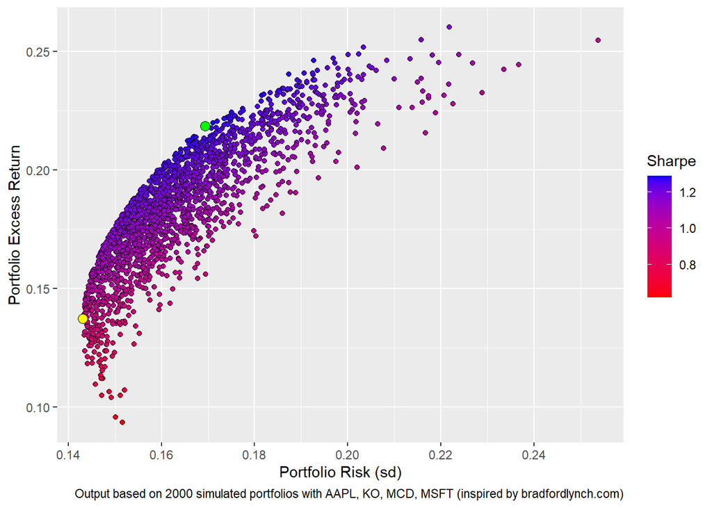

```r
# Plot the resulting portfolio returns and standard deviations
plot_mc = ggplot(risk_return, aes(x=SD, y=ER, fill=SR)) +

  # define observations to be dots
  geom_point(shape=21, color="black") +

  # color-fill the dots based on the level of the Sharpe Ratio
  scale_fill_gradient(low="red", high="blue", name="Sharpe") +

  # add the optimal risky portfolio
  geom_point(data=opt_p, aes(x=SD, y=ER), shape=21, size=3, fill="green") +

  # add the global minimum variance portfolio
  geom_point(data=gmv_p, aes(x=SD, y=ER), shape=21, size=3, fill="yellow") +

  # add x and y labels
  labs(x="Portfolio Risk (sd)", y="Portfolio Excess Return")

# Add a caption
plot_mc = plot_mc +
  labs(caption=paste("Output based on", num_portfolios,
                     "simulated portfolios with",
                     paste(colnames(rx_stocks), collapse = ", "),
                     "(inspired by bradfordlynch.com)"))

print(plot_mc)
```

.

.

# Complete Portfolio

.

The optimal *complete* portfolio is a mix between the optimal *risky* portfolio and a risk-free asset. It depends on your level of risk aversion.

.

If we are risk averse (`A>0`), what is the right mix between the optimal portfolio `opt_p` and any risk-free alternative?

.

We use here the derived optimal weight y* as seen in the lecture.

.

### Case 1: Risk-aversion parameter A = 10

```r
A = 10 # very risk averse

# The optimal share to invest in the risky portfolio
y_star_hi = opt_p$ER / (A*(opt_p$SD^2)) # rx = re-rf, so effectively use rf = 0

# Calculate portfolio return and risk
ret_hi    = y_star_hi * opt_p$ER + (1 - y_star_hi)*0
rsk_hi    = y_star_hi * opt_p$SD + (1 - y_star_hi)*0

print(paste('Optimal weight in risky portfolio (high risk aversion):', y_star_hi))
```

```
[1] "Optimal weight in risky portfolio (high risk aversion): 0.76190620128695"
```

**Note**

We do not need `rf` for the computation of `y_star`, because we are using *excess returns* `ER`. Also, `ER`and `SD` are annualized values already.

.

### Case 2: Risk-aversion parameter A = 5

```r
A = 5 # less risk averse

# The optimal share to invest in the risky portfolio
y_star_lo = opt_p$ER / (A*(opt_p$SD^2))

# Calculate portfolio return and risk
ret_lo    = y_star_lo * opt_p$ER
rsk_lo    = y_star_lo * opt_p$SD

print(paste('Optimal weight in risky portfolio (lower risk aversion):', y_star_lo))
```

```
[1] "Optimal weight in risky portfolio (lower risk aversion): 1.5238124025739"
```

.

.

## Capital Allocation Line (CAL)

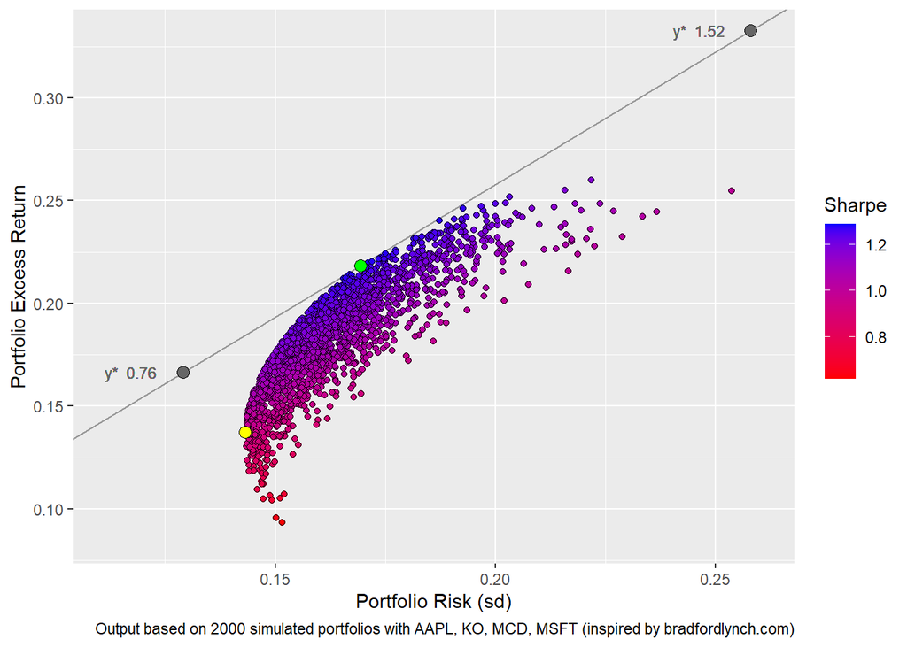

```r
# Plot the resulting portfolio returns and standard deviations
plot_mc = ggplot(risk_return, aes(x=SD, y=ER, fill=SR)) +

  # add the capital allocation line (intercept = 0 = rf, slope = SR)
  geom_abline(intercept=0, slope=opt_p$SR, color="grey60") +
  geom_point(shape=21, color="black") +

  # color-fill the dots based on the level of the Sharpe Ratio
  scale_fill_gradient(low="red", high="blue", name="Sharpe") +

  # add the optimal risky portfolio
  geom_point(data=opt_p, aes(x=SD, y=ER),
             shape=21, size=3, fill="green") +

  # add the global minimum variance portfolio
  geom_point(data=gmv_p, aes(x=SD, y=ER),
             shape=21, size=3, fill="yellow") +

  # add the optimal complete portfolio using A = 5 and A = 10
  geom_point(aes(x=rsk_lo, y=ret_lo),
             shape=21, size=3, fill="grey40") +
  geom_point(aes(x=rsk_hi, y=ret_hi),
             shape=21, size=3, fill="grey40") +
  geom_text(aes(x=rsk_lo, y=ret_lo,
            label=paste("y* ", round(y_star_lo,2))),
            vjust=0.5, hjust=1.5, color="grey40", size=3) +
  geom_text(aes(x=rsk_hi, y=ret_hi,
            label=paste("y* ", round(y_star_hi,2))),
            vjust=0.5, hjust=1.5, color="grey40", size=3) +

  # scale the axes
  scale_x_continuous(expand = expansion(add = c(0.025, 0.01))) +
  scale_y_continuous(expand = expansion(add = c(0.02, 0.01))) +

  # add x and y labels
  labs(x="Portfolio Risk (sd)", y="Portfolio Excess Return")

# Add a caption
plot_mc = plot_mc +
  labs(caption=paste("Output based on", num_portfolios,
                     "simulated portfolios with",
                     paste(colnames(rx_stocks), collapse = ", "),
                     "(inspired by bradfordlynch.com)"))

print(plot_mc)
```

.

.

# Bonus: Simulating Portfolio Weights (DIY)

**Important**

This part is beyond the scope of the data assignments and the exam. However, it is useful to see how we have generated the weights for the portfolios that we have just worked with. Monte Carlo simulation is a method that may come back during your master’s studies or be of value for your bachelor thesis.

## Monte Carlo Preparation

Monte Carlo method is a fancy name for introducing randomness (here: different portfolio weight combinations).

.

**Define the Monte Carlo parameters**

The initialization of the Monte Carlo simulation of the hypothetical portfolios requires defining parameters.

```r
# Parameters
num_stk = 4 # number of stocks

num_sim = 2000 # number of portfolios to simulate

set.seed(666) # to replicate randomization (!), optional
```

.

**Initialize storing the results**

Let us initialize an empty data frame to store the results.

Rows = number of simulations.  
Columns = weight in each stock (4 stocks)

```r
df104 = data.frame(matrix(nrow=num_sim, ncol=num_stk)) # df to save results

colnames(df104) = c(colnames(rx_stocks)) # give column names to the four stocks

View(df104)
```

.

## Monte Carlo Simulation

Ready to go!  
We loop over the number of simulations (=2000) and draw 4 random weights each time

.

**Creating random weights**

```r
# Loop over the number of simulations (here: 2000)
for (i in 1:num_sim) { # for 1, 2, 3, ..., to 2000

  # Obtain random weights
  weights = runif(num_stk)        # draw num_stk (= 4) uniform random numbers
  weights = weights / sum(weights)# make sure the weights sum to one

  # store the weights in the dataframe
  df104[i,1] = weights[1]
  df104[i,2] = weights[2]
  df104[i,3] = weights[3]
  df104[i,4] = weights[4]      # num_stk columns for weights
}
```

.

**Store as csv**

Finally, store the output as a csv file (which is the one uploaded on Canvas).

```r
# This will store the file in the folder where you have saved your R code
write.csv(df104,"df104.csv", row.names = FALSE)
```